# Time Series Minimum Wage Studies Meta-Analysis - Report

Gabriele Stella, Weida Pan

June, 2022

Economic theory suggests that a binding minimum price policy, including a minimum wage, should lead to an imbalance characterized by excess supply and reduced demand. Previous empirical research has questioned how well this prediction holds true in the labor market, with many estimates suggesting that raising the minimum wage would have an impact on employment.

The theory greatly simplifies the low-skilled labor market, generally assuming that all participants have the same skill level, resulting in equal job productivity. In fact, the minimum wage may be binding on the least skilled, least productive workers, but not more experienced workers in the same company. Determining the relevant markets to which employment reduction projections should apply becomes challenging empirically, especially when the data do not allow direct observation of wages.

# *Card and Krueger*’s Meta-Analysis

Meta analysis aims to use the main results of the same argument to verify whether the conclusions are generally valid. In such studies, authors usually look for various biases that may lead to wrong conclusions, which are later performed by other scientists.

In fact, in their paper, *card and krueger* tested what they called “one of the most famous predictions in standard economic theory”:

**The impact of the minimum wage on the employment.**

The economic literature debated this effect since 1970, it is well known that an increase in the minimum wage will lead to an increase in the unemployment rate of the weakest part of the workforce (*teenagers*)

This forecast indicates that a 10 per cent increase in the federal minimum wage will result in a 1 to 3 per cent reduction in youth employment.

Nevertheless, *Card and Krueger* found that if past studies are now accepted and regarded as credible, the prediction of this impact in some recent studies based on cross-sectional seemed to come to other conclusion. These studies predicted a null immpacts or sometimes a bit positive.

*Card and Krueger* thank to Meta-Analysis tool could test why the Time-Series studies kept to prove the reverse.

It is important to say that recent studies have more observations than previous studies. This is also due to historical reasons.

Their analysis is based on the assumption that the literature contains unbiased samples of coefficients and t ratios, because the sample sizes are different as described above.

Otherwise, their findings was difficult to reconcile with their null hypothesis, so they explain that this result may be due to the tendency for statistically significant results to be over represented in the published literature, the author’s to see publication their studying could (voluntarily or not) have been affected by publication bias and/or specification searching.

The authors chose the t-ratio on the minimum wage variable, in which the log scale was judged to be the preferred one. For studies that estimated only linear specifications, the authors chose t- ratios from the preferred linear specifications.

Since the functional form is one of the factors at the researcher’s discretion. Therefore, estimates can be combined based on different functional forms. However, the authors attempted to limit the sample to a subset of studies using log norms and came to similar conclusions.

Besides, the authors estimate the similarity models of three research subsets. In the subsample before 1982, he found that there was a negative correlation between T ratio and degrees of freedom. In addition, the regression analysis of omitting outliers was carried out. When this study was excluded from the sample, the relationship between T ratio and degrees of freedom became significant. After all, he analyzed a subset of 11 studies using the logarithmic norm. In this result, there is a negative correlation between t ratio and degrees of freedom.

# Our implementation

Having replicated the results obtained by Card and Krueger, we aimed to further strengthen the analysis by adding additional papers, paying particular attention to these papers, which were published later than previous meta-analyses.

The next section describes the process of reproducing the meta-analysis done by Card and Krueger. Later, we then conduct the analysis with three other papers and indicating our obtained results.

## Data Summarize

### Card and Krueger’s Data.

| id_num | implemented | author | year | t_stat | df | coef | teen_subsample | log_spec | no_exp_var | autoreg_correction | error | sqrt_df | l_sqrt_df |
| --- | --- | --- | --- | --- | --- | --- | --- | --- | --- | --- | --- | --- | --- |
| 1 | No | Kaitz | 1970 | 2.30 | 49 | 0.098 | NA | 0 | 10 | 0 | 0.0426087 | 7.000000 | 1.945910 |
| 2 | No | Mincer | 1976 | 2.41 | 58 | 0.231 | NA | 0 | 5 | 1 | 0.0958506 | 7.615773 | 2.030222 |
| 3 | No | Gramlich | 1976 | 1.41 | 106 | 0.094 | NA | 1 | 17 | 1 | 0.0666667 | 10.295630 | 2.331720 |
| 4 | No | Welch | 1976 | 2.22 | 53 | 0.178 | NA | 1 | 6 | 0 | 0.0801802 | 7.280110 | 1.985146 |
| 5 | No | Ragan | 1977 | 1.52 | 31 | 0.065 | NA | 1 | 8 | 1 | 0.0427632 | 5.567764 | 1.716994 |
| 6 | No | Wachter and Kim | 1979 | 2.17 | 56 | 0.252 | NA | 1 | 11 | 0 | 0.1161290 | 7.483315 | 2.012676 |
| 7 | No | Iden | 1980 | 4.43 | 93 | 0.226 | NA | 0 | 10 | 1 | 0.0510158 | 9.643651 | 2.266300 |
| 8 | No | Ragan | 1981 | 1.70 | 54 | 0.052 | NA | 1 | 9 | 1 | 0.0305882 | 7.348469 | 1.994492 |
| 9 | No | Abowd and Killingsworth | 1981 | 1.04 | 95 | 0.213 | NA | 1 | 8 | 0 | 0.2048077 | 9.746794 | 2.276938 |
| 10 | No | Betsey and Dunson | 1981 | 2.12 | 93 | 0.139 | NA | 0 | 10 | 1 | 0.0655660 | 9.643651 | 2.266300 |
| 11 | No | Brown | 1983 | 1.92 | 92 | 0.096 | NA | 1 | 11 | 0 | 0.0500000 | 9.591663 | 2.260894 |
| 12 | No | Hammermesh | 1981 | 1.63 | 94 | 0.121 | NA | 1 | 5 | 1 | 0.0742331 | 9.695360 | 2.271647 |
| 13 | No | Solon | 1985 | 2.78 | 86 | 0.098 | NA | 1 | 17 | 1 | 0.0352518 | 9.273618 | 2.227174 |
| 14 | No | Wellington | 1991 | 1.41 | 114 | 0.066 | NA | 1 | 17 | 1 | 0.0468085 | 10.677078 | 2.368099 |
| 15 | No | Klerman | 1992 | 0.45 | 123 | 0.052 | NA | 1 | 5 | 1 | 0.1155556 | 11.090537 | 2.406092 |

The studies used by *Card and Krueger* are:

- *Kaitz (1970)*; - *Mincer (1976)*; - *Gramlich, Flanagan, and Wachter (1976)*; - *Welch (1976)*; - *James F. Ragan (1977)*; - *Wachter and Kim (1979)*; - *Iden (1980)*; - *James F. Ragan (1981)*; - *Abowd and Killingsworth (1981)*; - *Betsey and Dunson (1981)*; - *Brown, Gilroy, and Kohen (1983)*; - *Hamermesh (1981)*; - *Solon (1985)*; - *Wellington (1991)*; - *Klerman (1992)*.

In the next session you can see the original Dataframe, the implemented data frame and the full dataframe aggregate; follow by a legend for the variable. Then we’re going to proceed with three more chapter, in each chapter you can see the model or graph estimated by *Card and Krueger* follow by the same study but on our implemented dataframe.

### Our implementation.

|  | id_num | implemented | author | year | t_stat | df | coef | teen_subsample | log_spec | no_exp_var | autoreg_correction | error | sqrt_df | l_sqrt_df |
| --- | --- | --- | --- | --- | --- | --- | --- | --- | --- | --- | --- | --- | --- | --- |
| 16 | 16 | Yes | Majchrowska and Żółkiewski | 2012 | 2.15 | 157 | 0.270 | 1 | 1 | 8 | 1 | 0.1255814 | 12.52996 | 2.528123 |
| 17 | 17 | Yes | Ni ,Wang & Yao | 2011 | 1.97 | 105 | 0.098 | 1 | 1 | 6 | 1 | 0.0497462 | 10.24695 | 2.326980 |
| 18 | 18 | Yes | Bewley et al. | 2015 | 1.46 | 128 | 0.072 | 1 | 1 | 10 | 1 | 0.0493151 | 11.31371 | 2.426015 |

Our result are based on sample size really huge, but their t-stat doesn’t seem highly significant and that’s in line with the *Card and Krueger* prediction.

In the next session you can see the original Dataframe, the implemented data frame and the full dataframe aggregate; follow by a legend for the variable. Then we’re going to proceed with three more chapter, in each chapter you can see the model or graph estimated by *Card and Krueger* follow by the same study but on our implemented dataframe.

### Meta analysis Data Frame

| id_num | implemented | author | year | t_stat | df | coef | teen_subsample | log_spec | no_exp_var | autoreg_correction | error | sqrt_df | l_sqrt_df |
| --- | --- | --- | --- | --- | --- | --- | --- | --- | --- | --- | --- | --- | --- |
| 1 | No | Kaitz | 1970 | 2.30 | 49 | 0.098 | NA | 0 | 10 | 0 | 0.0426087 | 7.000000 | 1.945910 |
| 2 | No | Mincer | 1976 | 2.41 | 58 | 0.231 | NA | 0 | 5 | 1 | 0.0958506 | 7.615773 | 2.030222 |
| 3 | No | Gramlich | 1976 | 1.41 | 106 | 0.094 | NA | 1 | 17 | 1 | 0.0666667 | 10.295630 | 2.331720 |
| 4 | No | Welch | 1976 | 2.22 | 53 | 0.178 | NA | 1 | 6 | 0 | 0.0801802 | 7.280110 | 1.985146 |
| 5 | No | Ragan | 1977 | 1.52 | 31 | 0.065 | NA | 1 | 8 | 1 | 0.0427632 | 5.567764 | 1.716994 |
| 6 | No | Wachter and Kim | 1979 | 2.17 | 56 | 0.252 | NA | 1 | 11 | 0 | 0.1161290 | 7.483315 | 2.012676 |
| 7 | No | Iden | 1980 | 4.43 | 93 | 0.226 | NA | 0 | 10 | 1 | 0.0510158 | 9.643651 | 2.266300 |
| 8 | No | Ragan | 1981 | 1.70 | 54 | 0.052 | NA | 1 | 9 | 1 | 0.0305882 | 7.348469 | 1.994492 |
| 9 | No | Abowd and Killingsworth | 1981 | 1.04 | 95 | 0.213 | NA | 1 | 8 | 0 | 0.2048077 | 9.746794 | 2.276938 |
| 10 | No | Betsey and Dunson | 1981 | 2.12 | 93 | 0.139 | NA | 0 | 10 | 1 | 0.0655660 | 9.643651 | 2.266300 |
| 11 | No | Brown | 1983 | 1.92 | 92 | 0.096 | NA | 1 | 11 | 0 | 0.0500000 | 9.591663 | 2.260894 |
| 12 | No | Hammermesh | 1981 | 1.63 | 94 | 0.121 | NA | 1 | 5 | 1 | 0.0742331 | 9.695360 | 2.271647 |
| 13 | No | Solon | 1985 | 2.78 | 86 | 0.098 | NA | 1 | 17 | 1 | 0.0352518 | 9.273618 | 2.227174 |
| 14 | No | Wellington | 1991 | 1.41 | 114 | 0.066 | NA | 1 | 17 | 1 | 0.0468085 | 10.677078 | 2.368099 |
| 15 | No | Klerman | 1992 | 0.45 | 123 | 0.052 | NA | 1 | 5 | 1 | 0.1155556 | 11.090537 | 2.406092 |
| 16 | Yes | Majchrowska and Żółkiewski | 2012 | 2.15 | 157 | 0.270 | 1 | 1 | 8 | 1 | 0.1255814 | 12.529964 | 2.528123 |
| 17 | Yes | Ni ,Wang & Yao | 2011 | 1.97 | 105 | 0.098 | 1 | 1 | 6 | 1 | 0.0497462 | 10.246951 | 2.326980 |
| 18 | Yes | Bewley et al. | 2015 | 1.46 | 128 | 0.072 | 1 | 1 | 10 | 1 | 0.0493151 | 11.313709 | 2.426015 |

In the next session you can see the original Dataframe, the implemented data frame and the full dataframe aggregate; follow by a legend for the variable. Then we’re going to proceed with three more chapter, in each chapter you can see the model or graph estimated by *Card and Krueger* follow by the same study but on our implemented dataframe.

## Variable

As we can see they used a set of 15 studies and we went to implement with three studies most recent.

- consists of the author(s),
- date of publication (year),
- t-statistic in absolute terms1 (t_stat),
- degrees of freedom (df),
- coefficient of the minimum wage variable in absolute terms2 (coef),
- number of explanatory variables of the model (no_exp_var),
- the error of the model (error) [Computing log and sqrt_log of error.]`
- and three dummy varibale:
  - log_spec
    - this variable is set to 1 when the author used a logarithmic specification for the model
  - autoreg_correction
    - this is set to 1, when the autoregression correction was applied
  - teen_subsample
    - this variable is set to one when the authors used a teen sumbsample, unfortunatly we didn’t find enough information to fill the missing data.

# Reproducing Part

The authors implemented this study focusing on three cases:

## 1 Relation of Estimated t-Ratio to Sample Size

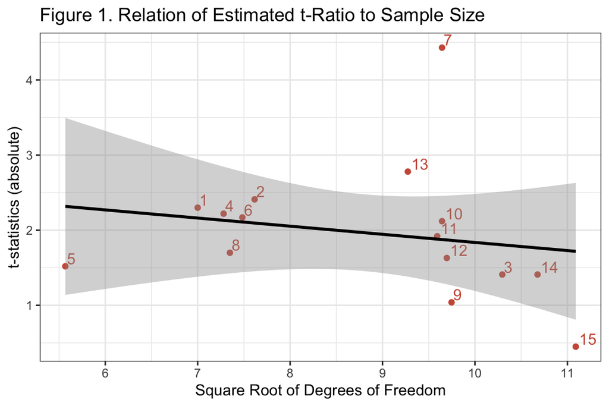

## 2 Descreptive Regression Models

[figure not shown]

## 3 Relation of Estimated Employment to Standard Error

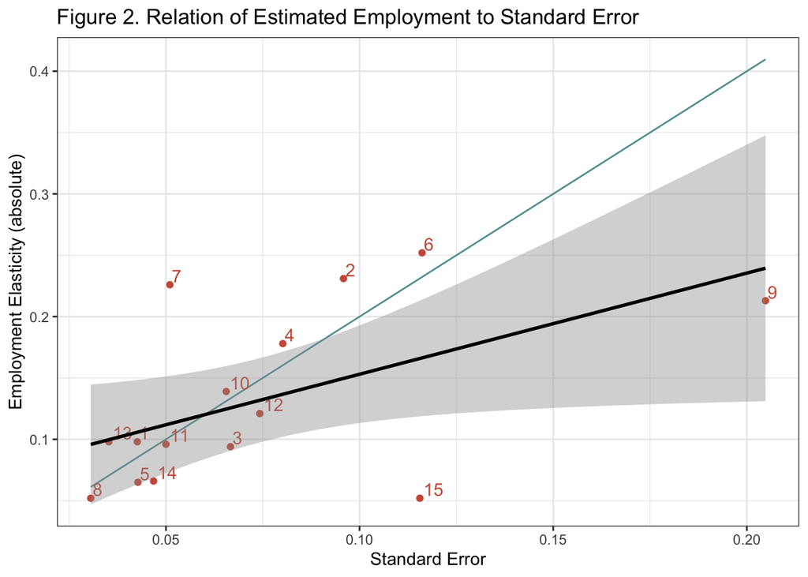

# Implementation

In our implementation, we need to control the potential impact of other research features on this dependence, so we use the logarithm of the absolute t ratio as the dependent variable for regression. Next, we select the independent variables, namely the logarithm of the square root of the degree of freedom, and the binary variables indicating whether the model specification in a given study is logarithm. This specification is similar to that used in the original meta-analysis, except that we did not find information about the adolescent subsample used in all papers.

We usually see that the model fitted on the subset is similar to the model described in the original meta-analysis and has the same direction. In all specifications, with our research, the coefficient is close to zero. However, for all replication models and extended models, the coefficient of the key independent variable, that is, the logarithm of the square root of the degree of freedom, is negative and far from 1, which again indicates that there is a deviation in the selected paper. For unbiased analysis, the coefficient should be equal to 1, because the higher the degree of freedom, the higher the t statistic. Here, we observe the opposite relationship.

## 1 Relation of Estimated t-Ratio to Sample Size- Implemented

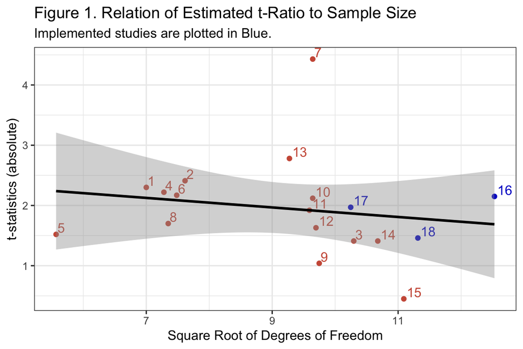

## 2 Descreptive Regression Models- Implemented

[figure not shown]